# Familarizing with R/RStudio

Module 1 In-class Assignment 2

# About the assignment.

In this assignment you will learn to bring in a dataset using the url. The assignment is in a RMarkdown file and give you a glimpse of working with RMarkdown. We will learn how to work with RMarkdown in details in our subsequent class. The advantage of a Rmarkdown file is that you can put your narrative along with the code and output in the same file. This cannot be done in an .R script without using the `#comment`. For this assignment, in the sections where you will need the R code to produce the required results, the blank R code chunks have been inserted. Write the R code in those sections as you would have done in the R console. Use the green triangle in the top right corner of each chunk to run your code or you can run the code in the console window and insert it in the code chunk thereafter. Once all the codes have been inserted, run the file and knit it thereafter. Please remember to change the author name to your group number at the beginning of the file. The html file is for your reference. The knitted html file should be similar to the one provided in D2L but will have the appropriate group number in the author section.

# Information on the `WorldBank` dataset.

This database gives information on different demographics for countries in the world.

```
[1] "/Users/kaitlynwatson/Downloads"
```

|  | iso2c | country | year | fertility.rate | life.expectancy | population | GDP.per.capita.Current.USD | X15.to.25.yr.female.literacy | iso3c | region | capital | longitude | latitude | income | lending |
| --- | --- | --- | --- | --- | --- | --- | --- | --- | --- | --- | --- | --- | --- | --- | --- |
| 1 | AD | Andorra | 1978 | NA | NA | 33746 | 9127.612 | NA | AND | Europe & Central Asia (all income levels) | Andorra la Vella | 1.5218 | 42.5075 | High income: nonOECD | Not classified |
| 2 | AD | Andorra | 1979 | NA | NA | 34819 | 11819.646 | NA | AND | Europe & Central Asia (all income levels) | Andorra la Vella | 1.5218 | 42.5075 | High income: nonOECD | Not classified |
| 3 | AD | Andorra | 1977 | NA | NA | 32769 | 7751.169 | NA | AND | Europe & Central Asia (all income levels) | Andorra la Vella | 1.5218 | 42.5075 | High income: nonOECD | Not classified |
| 4 | AD | Andorra | 2007 | 1.18 | NA | 81292 | 39922.890 | NA | AND | Europe & Central Asia (all income levels) | Andorra la Vella | 1.5218 | 42.5075 | High income: nonOECD | Not classified |
| 5 | AD | Andorra | 1976 | NA | NA | 31781 | 7151.574 | NA | AND | Europe & Central Asia (all income levels) | Andorra la Vella | 1.5218 | 42.5075 | High income: nonOECD | Not classified |
| 6 | AD | Andorra | 2011 | NA | NA | 77865 | NA | NA | AND | Europe & Central Asia (all income levels) | Andorra la Vella | 1.5218 | 42.5075 | High income: nonOECD | Not classified |

**How many variables are there in the dataset?** 15 Hint: use `ncol`

**What are the names of the different variables in the dataset?** [1] “iso2c” “country” “year”  
[4] “fertility.rate” “life.expectancy” “population”  
[7] “GDP.per.capita.Current.USD” “X15.to.25.yr.female.literacy” “iso3c”  
[10] “region” “capital” “longitude”  
[13] “latitude” “income” “lending”  
> **Identify the types of the different variables.** Character (chr), Integer (int), Number (num) Hint check function `names`, `str`.

# what are the types of the different variables?

Character, Number, Integer **What is the timeframe of the database?**

Hint can use the min and max function

1960 2014

**What is the dimension of the dataset?** Hint use the dim() function. rows 11880 columns 15

**Extract the information for rows 15 of the database.** iso2c country year fertility.rate life.expectancy population 15 AD Andorra 1989 NA NA 52449 GDP.per.capita.Current.USD X15.to.25.yr.female.literacy iso3c 15 15166.91 NA AND region capital longitude latitude 15 Europe & Central Asia (all income levels) Andorra la Vella 1.5218 42.5075 income lending 15 High income: nonOECD Not classified >

**Extract the information for rows 55:65 of the database.** iso2c country year fertility.rate life.expectancy population 55 AD Andorra 1993 NA NA 61003 56 AE United Arab Emirates 1960 6.928 52.24322 89608 57 AE United Arab Emirates 1967 6.783 59.34046 167360 58 AE United Arab Emirates 1968 6.738 60.24405 180762 59 AE United Arab Emirates 1961 6.910 53.28656 97727 60 AE United Arab Emirates 1966 6.816 58.39185 156890 61 AE United Arab Emirates 1971 6.512 62.65495 272211 62 AE United Arab Emirates 1972 6.402 63.36632 322439 63 AE United Arab Emirates 1973 6.279 64.04312 382599 64 AE United Arab Emirates 1974 6.146 64.68890 452848 65 AE United Arab Emirates 1962 6.893 54.32700 108774 GDP.per.capita.Current.USD X15.to.25.yr.female.literacy iso3c 55 16508.87 NA AND 56 NA NA ARE 57 NA NA ARE 58 NA NA ARE 59 NA NA ARE 60 NA NA ARE 61 NA NA ARE 62 NA NA ARE 63 NA NA ARE 64 NA NA ARE 65 NA NA ARE region capital longitude latitude 55 Europe & Central Asia (all income levels) Andorra la Vella 1.5218 42.5075 56 Middle East & North Africa (all income levels) Abu Dhabi 54.3705 24.4764 57 Middle East & North Africa (all income levels) Abu Dhabi 54.3705 24.4764 58 Middle East & North Africa (all income levels) Abu Dhabi 54.3705 24.4764 59 Middle East & North Africa (all income levels) Abu Dhabi 54.3705 24.4764 60 Middle East & North Africa (all income levels) Abu Dhabi 54.3705 24.4764 61 Middle East & North Africa (all income levels) Abu Dhabi 54.3705 24.4764 62 Middle East & North Africa (all income levels) Abu Dhabi 54.3705 24.4764 63 Middle East & North Africa (all income levels) Abu Dhabi 54.3705 24.4764 64 Middle East & North Africa (all income levels) Abu Dhabi 54.3705 24.4764 65 Middle East & North Africa (all income levels) Abu Dhabi 54.3705 24.4764 income lending 55 High income: nonOECD Not classified 56 High income: nonOECD Not classified 57 High income: nonOECD Not classified 58 High income: nonOECD Not classified 59 High income: nonOECD Not classified 60 High income: nonOECD Not classified 61 High income: nonOECD Not classified 62 High income: nonOECD Not classified 63 High income: nonOECD Not classified 64 High income: nonOECD Not classified 65 High income: nonOECD Not classified

## Regions of the World

The major demographic areas included in the database: Hint try using the `unique`

[1] “Europe & Central Asia (all income levels)”  
[2] “Middle East & North Africa (all income levels)” [3] “South Asia”  
[4] “Latin America & Caribbean (all income levels)” [5] “Sub-Saharan Africa (all income levels)”  
[6] “East Asia & Pacific (all income levels)”  
[7] NA  
[8] “North America”

Form a data frame using the latitude and longitude for one unique region. Example: Here the latitude and longitude for *North America* is given below:

| latNA | longtNA |
| --- | --- |
| NA | NA |
| 32.3293 | -64.7060 |
| 45.4215 | -75.6919 |
| 38.8895 | -77.0320 |

latNA longtNA 1 NA NA 2 32.3293 -64.7060 3 45.4215 -75.6919 4 38.8895 -77.0320

**Select another region and give the latitude and longitude for that region. Please be sure to mention which region was selected.** latNA longtNA 1 34.52280 69.1761 2 NA NA 3 23.70550 90.4113 4 27.57680 89.6177 5 28.63530 77.2250 6 6.92148 79.8528 7 4.17420 73.5109 8 27.69390 85.3157 9 30.51670 72.8000

# Visual analysis of fertility and Life-expectancy data comparing two given years.

## Create the plots and give the comparison for years 1960 vs 1975.

#### Plots

**Year 1960**

The first six rows of the dataframe consisting of the fertility and life expectancy from the `WorldBank` data for the year 1960 is given by:

|  | fertility_60 | lifeexp_60 |
| --- | --- | --- |
| 1 | NA | NA |
| 2 | 6.928 | 52.24322 |
| 3 | 7.671 | 31.58005 |
| 4 | 4.425 | 61.78273 |
| 5 | 6.186 | 62.25437 |
| 6 | 4.550 | 65.86346 |

fertility_60 lifeexp_60 1 NA NA 2 6.928 52.24322 3 7.671 31.58005 4 4.425 61.78273 5 6.186 62.25437 6 4.550 65.86346

In this section we will plot the data for fertility and life expectancy

The simple plot for fertility vs life expectancy for **1960**.

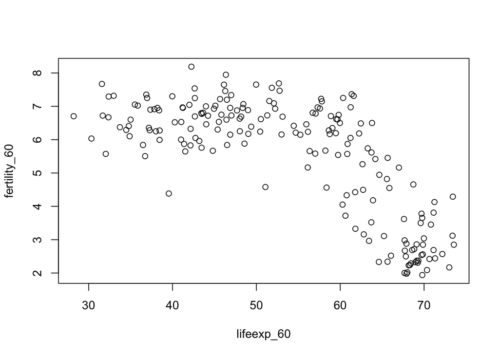

plot(lifeexp_60, fertility_60)

The enhanced plot of the **1960** data for fertility and life expectancy based on the population size.

[figure not shown]

```r
#population and region for 1960
pop_60 <- WorldBank$population[WorldBank$year == 1960]
region_60 <- WorldBank$region[WorldBank$year == 1960]
plot(lifeexp_60, fertility_60, type="n")
```

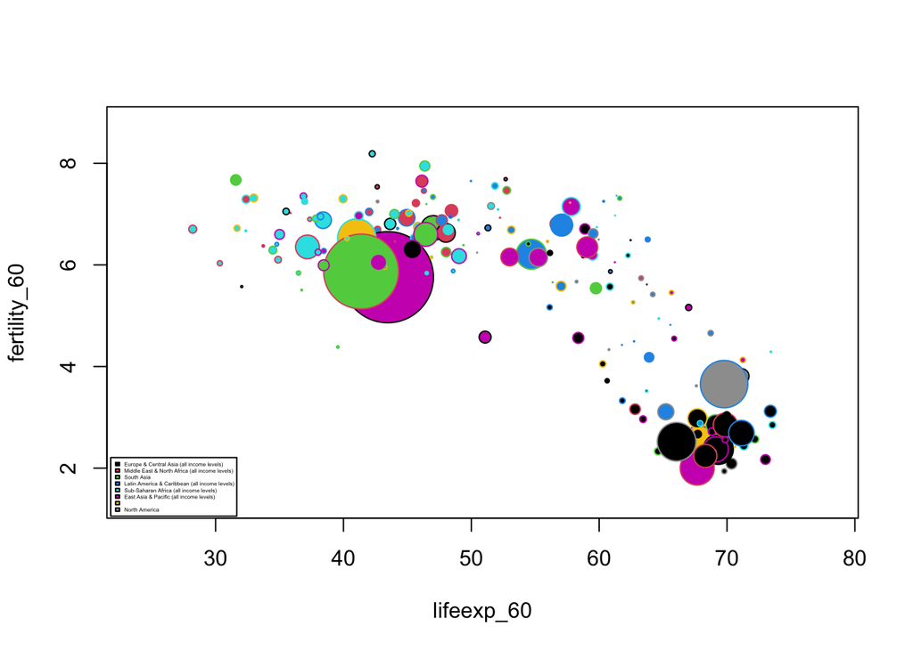

```r
symbols(lifeexp_60, fertility_60, circles =sqrt(pop_60/pi), inches=0.35,fg=1:8, bg=match(region_60, unique(region_60)))
legend("bottomleft", inset=0.005,
       unique(region_60), fill=1:8, cex=0.25)
```

pop_60 <- WorldBank$population[WorldBank$year == 1960] > region_60 <- WorldBank$region[WorldBank$year == 1960] > plot(lifeexp_60, fertility_60, type=“n”) > symbols(lifeexp_60, fertility_60, circles =sqrt(pop_60/pi), inches=0.35,fg=1:8, bg=match(region_60, unique(region_60))) > legend(“bottomleft”, inset=0.005, + unique(region_60), fill=1:8, cex=0.25)

**In the `plot` function above, What does the `type="n"` signify ?**

Type=n does not allow the graph to produce any lines on the graph.

**Year 1975**

The first six rows of the dataframe consisting of the fertility and life expectancy from the `WorldBank` data for the year 1975 is given by:

|  | fertility_75 | lifeexp_75 |
| --- | --- | --- |
| 1 | NA | NA |
| 2 | 6.009 | 65.30515 |
| 3 | 7.671 | 38.97027 |
| 4 | 2.701 | 67.13007 |
| 5 | 4.393 | 68.74122 |
| 6 | 2.745 | 70.53193 |

fertility_75 lifeexp_75 1 NA NA 2 6.009 65.30515 3 7.671 38.97027 4 2.701 67.13007 5 4.393 68.74122 6 2.745 70.53193

The simple plot for fertility vs life expectancy for **1975**.

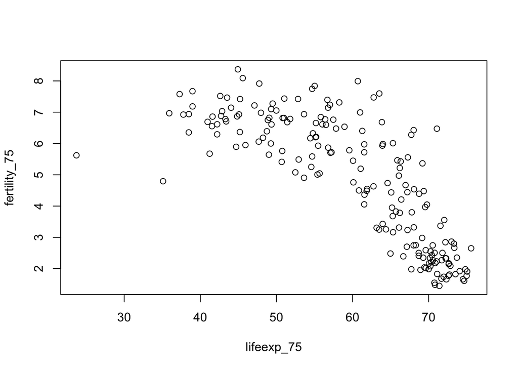

plot(lifeexp_75, fertility_75)

The enhanced plot of the **1975** data for fertility and life expectancy based on the population size.

[figure not shown]

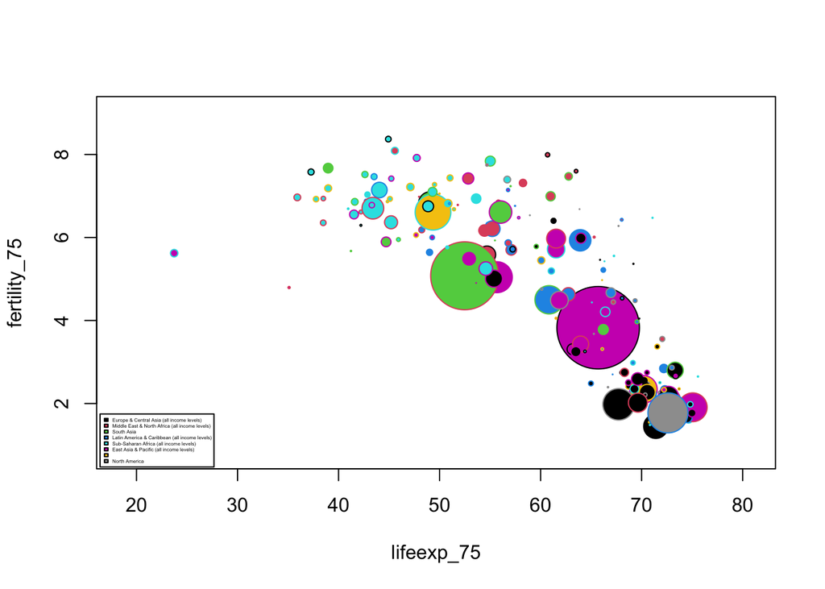

plot(lifeexp_75, fertility_75) > pop_75 <- WorldBank$population[WorldBank$year == 1975] > region_75 <- WorldBank$region[WorldBank$year == 1975] > plot(lifeexp_75, fertility_75, type=“n”) > symbols(lifeexp_75, fertility_75, circles = sqrt(pop_75/pi), inches=0.35,fg = 1:8,bg=match(region_75, unique(region_75))) > legend(“bottomleft”, inset=0.005, + unique(region_75), fill=1:8, cex=0.25)

#### Comparison of fertility and life-expectancy data

**Comment on the trend, shift and visible change in densities based on population (3-4 lines) for the two years (1960 vs 1975).**

The life expectancy was lower in 1960, then in 1975. Then people were having less children in 1975. (This is all inferred due to the fact the units are not listed)

## Create the plots and give the comparison for years 1965 vs 1980.

*Year 1965* fertility_65 lifeexp_65 1 NA NA 2 6.841 57.40571 3 7.671 34.15368 4 4.193 63.75607 5 5.594 65.82739 6 3.979 67.99154 > ```plot(lifeexp_65, fertility_65)

pop_65 <- WorldBank$population[WorldBank$year == 1965] > region_65 <- WorldBank$region[WorldBank$year == 1965] > plot(lifeexp_65, fertility_65, type=“n”) > symbols(lifeexp_65, fertility_65, circles =sqrt(pop_65/pi), inches=0.35,fg=1:8, bg=match(region_65, unique(region_65))) > legend(“bottomleft”, inset=0.005, + unique(region_65), fill=1:8, cex=0.25)

*Year 1980* fertility_80 lifeexp_80 1 NA NA 2 5.423 67.98320 3 7.669 41.23366 4 2.115 68.59198 5 3.678 70.23598 6 2.385 70.68454

plot(lifeexp_80, fertility_80)

pop_80 <- WorldBank$population[WorldBank$year == 1980] > region_80 <- WorldBank$region[WorldBank$year == 1980] > plot(lifeexp_80, fertility_80, type=“n”) > symbols(lifeexp_80, fertility_80, circles =sqrt(pop_80/pi), inches=0.35,fg=1:8, bg=match(region_80, unique(region_80))) > legend(“bottomleft”, inset=0.005, + unique(region_80), fill=1:8, cex=0.25)

*Year 1970*

fertility_70 lifeexp_70 1 NA NA 2 6.605 59.34046 3 7.671 35.17007 4 3.684 64.48807 5 5.050 66.28722 6 3.208 68.83049

plot(lifeexp_70, fertility_70)

pop_70 <- WorldBank$population[WorldBank$year == 1970] > region_70 <- WorldBank$region[WorldBank$year == 1970] > plot(lifeexp_70, fertility_70, type=“n”) > symbols(lifeexp_70, fertility_70, circles =sqrt(pop_70/pi), inches=0.35,fg=1:8, bg=match(region_70, unique(region_70))) > legend(“bottomleft”, inset=0.005, + unique(region_70), fill=1:8, cex=0.25)

*Year 2008* fertility_08 lifeexp_08 1 1.250 NA 2 1.948 76.21476 3 6.196 58.60710 4 2.164 74.98688 5 1.761 76.63232 6 1.734 73.94388

plot(lifeexp_08, fertility_08)

plot(lifeexp_08, fertility_08) > pop_08 <- WorldBank$population[WorldBank$year == 2008] > region_08 <- WorldBank$region[WorldBank$year == 2008] > plot(lifeexp_08, fertility_08, type=“n”) > symbols(lifeexp_08, fertility_08, circles = sqrt(pop_08/pi), inches=0.08,fg = 1:8,bg=match(region_08, unique(region_08))) > legend(“bottomleft”, inset=0.005, + unique(region_08), fill=1:8, cex=0.25)

# Essential details

## Deadline and submission

The M1 ICA2 is an in-class **group** assignment. However, each member of the group who worked together in class will submit their in-class assignment at the end of the class time. Submit your work by uploading both your RMD and HTML/PDF files through D2L. Although the expectation is to get it done within the class period, if a group needs a little bit of extra time to finish, they can submit the assignment on or before **11 PM of Sept 8,2021**. Late work after this deadline will not be accepted except under certain extraordinary circumstances.

## Grading

ICAs are graded for participation and completion. Each team member who was present in class and worked on the ICA should submit their files. To grade the ICAs, the instructional team will pick one submission at random from each group. Thus it is important that there is good intra-group communication and teamwork. Each group should ensure that everyone in the team understood, worked through and completed the assignment.